# Associacion rules analysis of delivery services

Maria Janiszewska

## Introduction

In this document I will present analysis on dataset “E-Commerce Shipping Data” from https://www.kaggle.com/prachi13/customer-analytics. The main goal is to find association rules (that is set of characteristics) for the level of customer’s satisfation. The analysis will mostly base on The Apriori algorithm.

## Data preparation

Used packages:

```r
library(arules)
library(arulesViz)
library(arulesCBA)
```

In order to be able to conduct market basket analysis I transformed data from continuous to categorical. Changes are presented below.

```r
data_raw <- read.csv("shipping_data.csv", sep=",", skip=0)


data_raw$rating <- ifelse(data_raw[,5]<3, "not satisfied", ifelse(data_raw[,5]<5, "quite satisfied","very satisfied"))
data_raw$discount <- ifelse(data_raw[,10]<4, "no or very small discount", ifelse(data_raw[,10]<7, "small discount", ifelse(data_raw[,10]<10, "medium discount", "big discount")))
data_raw$price <- ifelse(data_raw[,6]<169, "cheap product", ifelse(data_raw[,6]<214, "medium price product", ifelse(data_raw[,6]<251, "expensive product", "very expensive product")))
data_raw$type_of_client <- ifelse(data_raw[,7]<1, "new client", ifelse(data_raw[,7]<4, "few purchases", "regular customer"))
data_raw$weight <- ifelse(data_raw[,11]<1840, "light package", ifelse(data_raw[,11]<4149,"medium weight package", ifelse(data_raw[,11]<5050, "heavy package", "very heavy package")))
data_raw$on_time <- ifelse(data_raw[,12]==0, "on time delivery", "late delivery")
data_raw$Gender <- ifelse(data_raw[,9]=="M", "Male", "Female")
```

The dataset has 10999 observations and 9 columns that represents characteristics:  
1. Gender - male or female  
2. Warehouse_block - warehouse from where the package was sent (A-F)  
3. Product importance - (low, medium, high)  
4. Rating - not satisfied (1-2 stars), quite satisfied (3-4 stars), very satisfied (5 stars)  
5. Discount - divided based on quartiles of the group: no or very small discount (< 3%), small discount (4%-6%), medium discount (7%-9%), big discount (>10)  
6. Price of product - divided based on quartiles of the group: cheap product (0-168), medium price product (169-213), expensive product (214-250), very expensive product (251<)  
7. Type of client - how many times customer have used the service: new client (0), few purchases (1-3), regular customer (4<)  
8. Weight - divided based on quartiles of the group: light package (0-1839), medium weight package (1840-4148), heavy package (4149-5049), very heavy package (5050<)  
9. On time - late delivery, on time

```r
data <- data_raw[,c(2,3,8,9,13,14,16:18)]
head(data)
```

```
##   Warehouse_block Mode_of_Shipment Product_importance Gender          rating
## 1               D           Flight                low Female   not satisfied
## 2               F           Flight                low   Male  very satisfied
## 3               A           Flight                low   Male   not satisfied
## 4               B           Flight             medium   Male quite satisfied
## 5               C           Flight             medium Female   not satisfied
## 6               F           Flight             medium Female   not satisfied
##       discount   type_of_client                weight       on_time
## 1 big discount    few purchases         light package late delivery
## 2 big discount    few purchases medium weight package late delivery
## 3 big discount regular customer medium weight package late delivery
## 4 big discount regular customer         light package late delivery
## 5 big discount    few purchases medium weight package late delivery
## 6 big discount    few purchases         light package late delivery
```

After preparing the dataset I saved it and import again as transactions. As is presented below, each transaction (delivery service) are determined by some characteristics.

```r
trans <- read.transactions("shipping.csv", format="basket", sep=",", skip=0, header = T)
trans
```

```
## transactions in sparse format with
##  10999 transactions (rows) and
##  32 items (columns)
```

```r
inspect(head(trans))
```

```
##     items
## [1] {big discount,
##      D,
##      Female,
##      few purchases,
##      Flight,
##      late delivery,
##      light package,
##      low,
##      medium price product,
##      not satisfied}
## [2] {big discount,
##      expensive product,
##      F,
##      few purchases,
##      Flight,
##      late delivery,
##      low,
##      Male,
##      medium weight package,
##      very satisfied}
## [3] {A,
##      big discount,
##      Flight,
##      late delivery,
##      low,
##      Male,
##      medium price product,
##      medium weight package,
##      not satisfied,
##      regular customer}
## [4] {B,
##      big discount,
##      Flight,
##      late delivery,
##      light package,
##      Male,
##      medium,
##      medium price product,
##      quite satisfied,
##      regular customer}
## [5] {big discount,
##      C,
##      Female,
##      few purchases,
##      Flight,
##      late delivery,
##      medium,
##      medium price product,
##      medium weight package,
##      not satisfied}
## [6] {big discount,
##      cheap product,
##      F,
##      Female,
##      few purchases,
##      Flight,
##      late delivery,
##      light package,
##      medium,
##      not satisfied}
```

## Analysis

### Method

To conduct the analysis I used The Apriori algorithm one of the Association rules analysis methods. It enables to find associations between the characteristics of each delivery service. In other words to find the sets of characteristics that are linked to similar types of baskets. In this case sets of characteristics which are highly associated with each of 3 levels of customer’s satisfaction.

To check how frequently was each characteristics in the dataset I created the percentage table presented below. As we can see the most (68%) are shipped by Ship, delivery was late (60%) and the customer is the person that used this delivery service few times so is not a new customer and not a regular. Additionally we can see that customers were divided equally - 50% male and 50% female.

```r
sort(round(itemFrequency(trans),3), decreasing = T)
```

```
##                      Ship             late delivery             few purchases
##                     0.678                     0.597                     0.596
##                    Female                      Male                       low
##                     0.504                     0.496                     0.482
##                    medium          regular customer          on time delivery
##                     0.432                     0.404                     0.403
##           quite satisfied             not satisfied                         F
##                     0.403                     0.400                     0.333
##              big discount    very expensive product      medium price product
##                     0.319                     0.253                     0.252
##         expensive product             heavy package             light package
##                     0.251                     0.250                     0.250
##     medium weight package        very heavy package             cheap product
##                     0.250                     0.250                     0.244
## no or very small discount           medium discount            small discount
##                     0.229                     0.226                     0.226
##            very satisfied                         A                         B
##                     0.197                     0.167                     0.167
##                         C                         D                    Flight
##                     0.167                     0.167                     0.162
##                      Road                      high
##                     0.160                     0.086
```

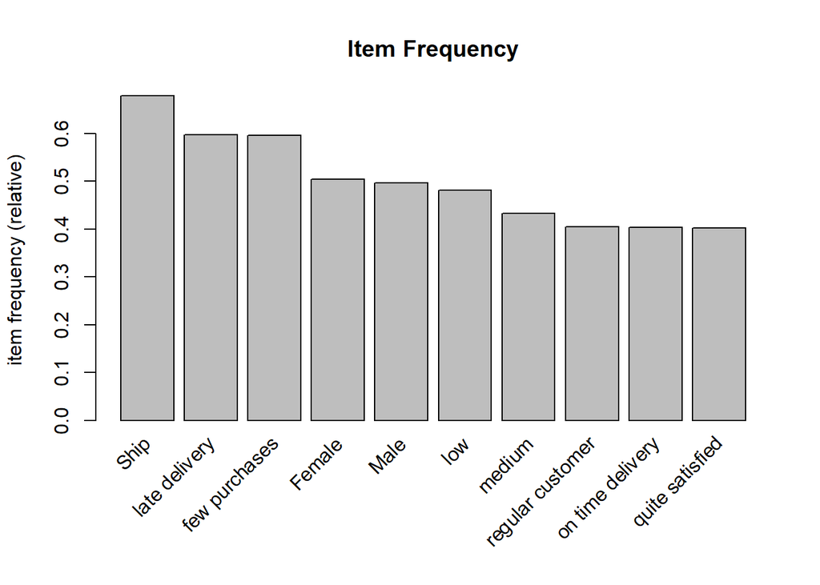

```r
itemFrequencyPlot(trans, topN=10, type="relative", main="Item Frequency")
```

#### Jaccard Index

Jaccard Index indicated similarity of the characteristics. Below there is an dendrogram for them. There are a lot of groups with different number of characteristics. Not satisfied are close to males and low importance, however very satisfied is close to cheap products. As one can see similar characteristics are not intuitive which makes it hard to analyze.

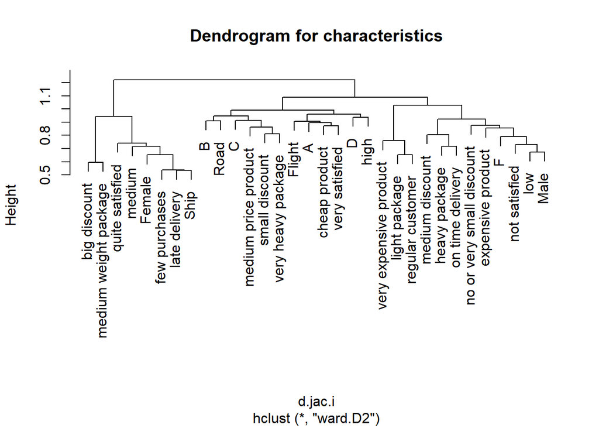

```r
trans.sel<-trans[,itemFrequency(trans)>0.05]
d.jac.i <- dissimilarity(trans.sel, which="items")
plot(hclust(d.jac.i, method="ward.D2"), main="Dendrogram for characteristics")
```

### Results

First thing I will present is identifying characteristics of delivery service for each lever of customer’s satisfaction to see some obvious and visible associations. The association will be measured by confidence level, which indicates how two objects are linked with each other, what means that how frequently they are in the same delivery service.

#### For which delivery services customers were very satisfied?

According to the results below we can say that deliveries which were on time got the highest scores for male customers. Usually they were shipped by Plane and from the F warehouse.

Confidence level is not high for the 6 first rules, which means that the rules are not very strong. The highest value (66.7%) is for the characteristics: A warehouse, few purchases, Flight, on time delivery, small discount.

```r
rules.verySatis <- apriori(data=trans, parameter=list(supp=0.001, conf=0.008), appearance=list(default="lhs", rhs="very satisfied"), control=list(verbose=F))
rules.verySatis.byconf<-sort(rules.verySatis, by="confidence", decreasing=TRUE)
inspect(head(rules.verySatis.byconf))
```

```
##     lhs                            rhs                  support confidence    coverage     lift count
## [1] {A,
##      few purchases,
##      Flight,
##      on time delivery,
##      small discount}            => {very satisfied} 0.001272843  0.6666667 0.001909264 3.377553    14
## [2] {F,
##      Flight,
##      low,
##      Male,
##      no or very small discount,
##      on time delivery}          => {very satisfied} 0.001000091  0.6470588 0.001545595 3.278213    11
## [3] {cheap product,
##      F,
##      Flight,
##      low,
##      Male,
##      on time delivery}          => {very satisfied} 0.001181926  0.5909091 0.002000182 2.993740    13
## [4] {F,
##      Flight,
##      low,
##      Male,
##      on time delivery,
##      regular customer}          => {very satisfied} 0.001181926  0.5909091 0.002000182 2.993740    13
## [5] {F,
##      Flight,
##      low,
##      no or very small discount,
##      on time delivery}          => {very satisfied} 0.001272843  0.5600000 0.002272934 2.837144    14
## [6] {F,
##      Flight,
##      heavy package,
##      low,
##      Male,
##      on time delivery}          => {very satisfied} 0.001272843  0.5600000 0.002272934 2.837144    14
```

In the picture below one can see that confidence level rises along with the lift value, which is in the range 0.5 to 4. Lift value indicates, how much more likely is that a service, which is rated very high, has certain characteristics than when they are separated.

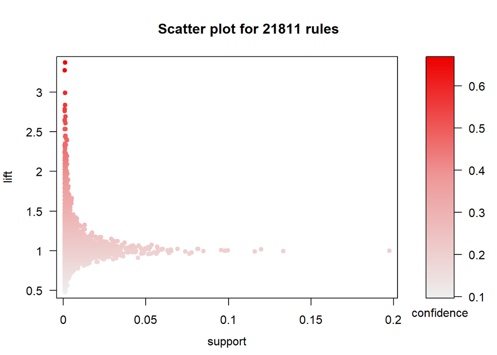

```r
plot(rules.verySatis, measure=c("support","lift"), shading="confidence", jitter = 0)
```

#### For which delivery services customers were quite satisfied?

Less satisfied customers received the delivery of a product that was medium price which was from $170 to $214. It’s hard to say more about this scenario because the characteristics do not occur several times or there are more than one. Better idea will be to compare characteristics only of very satisfied and no satisfied customers.

```r
rules.quiteSatif <- apriori(data=trans, parameter=list(supp=0.001, conf=0.08), appearance=list(default="lhs", rhs="quite satisfied"), control=list(verbose=F))
rules.quiteSatif.byconf <- sort(rules.quiteSatif, by="confidence", decreasing=TRUE)
inspect(head(rules.quiteSatif.byconf))
```

```
##     lhs                            rhs                   support confidence    coverage     lift count
## [1] {D,
##      few purchases,
##      late delivery,
##      low,
##      medium price product,
##      very heavy package}        => {quite satisfied} 0.001181926  0.8666667 0.001363760 2.152770    13
## [2] {heavy package,
##      Male,
##      medium,
##      medium price product,
##      no or very small discount,
##      regular customer,
##      Ship}                      => {quite satisfied} 0.001091008  0.8571429 0.001272843 2.129113    12
## [3] {C,
##      heavy package,
##      medium price product,
##      on time delivery,
##      Road}                      => {quite satisfied} 0.001000091  0.8461538 0.001181926 2.101817    11
## [4] {C,
##      Female,
##      heavy package,
##      medium price product,
##      Road}                      => {quite satisfied} 0.001000091  0.8461538 0.001181926 2.101817    11
## [5] {D,
##      late delivery,
##      Male,
##      medium discount,
##      medium price product,
##      Ship}                      => {quite satisfied} 0.001000091  0.8461538 0.001181926 2.101817    11
## [6] {few purchases,
##      heavy package,
##      late delivery,
##      low,
##      medium discount,
##      Ship,
##      very expensive product}    => {quite satisfied} 0.001000091  0.8461538 0.001181926 2.101817    11
```

Values of lift presented on the picture below indicates that only a few rules have values above 2. This confirms thesis above, that it is hard to point out characteristics of these deliveries that got 3 or 4 stars from the customer.

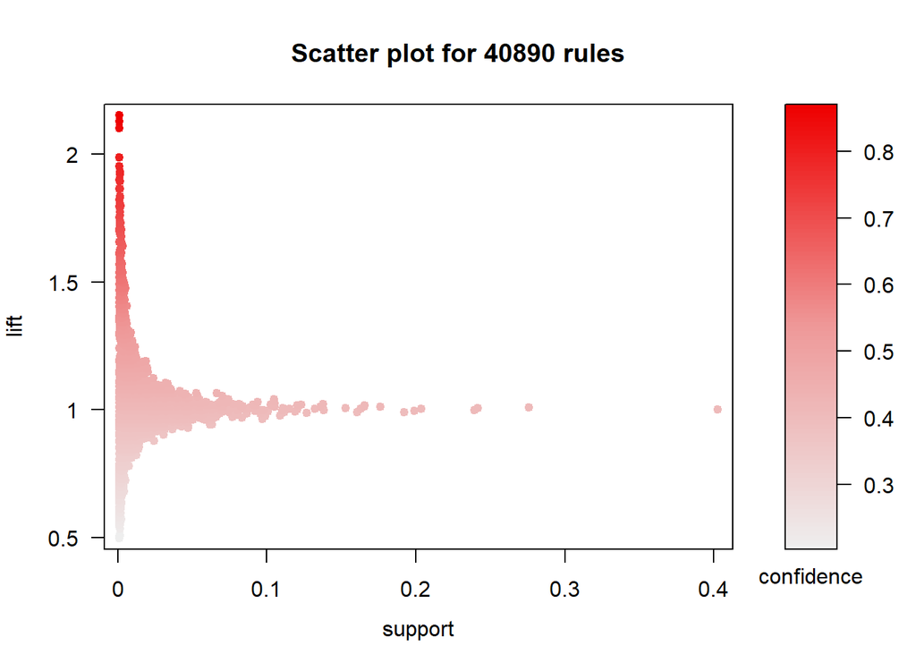

```r
plot(rules.quiteSatif, measure=c("support","lift"), shading="confidence", jitter = 0)
```

#### For which delivery services customers were not satisfied?

For the lowest rated delivery services rules are quite different. We can see that mostly they are from A warehouse (less from B) and delivered by road transport. Customers who gave such a low rating were males and the packages that they ordered were medium importance.

Confidence level is quite high for the 6 first rules The highest value (92.9%) is for the characteristics: A warehouse, light package, male, medium importance, regular consumer, road transport. There is a possibility that there are a lot more important rules because of the high level of confidence, thus there is an incentive to do some more research on the patters.

```r
rules.notSatif <- apriori(data=trans, parameter=list(supp=0.001, conf=0.08), appearance=list(default="lhs", rhs="not satisfied"), control=list(verbose=F))
rules.notSatif.byconf <- sort(rules.notSatif, by="confidence", decreasing=TRUE)
inspect(head(rules.notSatif.byconf))
```

```
##     lhs                            rhs                 support confidence    coverage     lift count
## [1] {A,
##      light package,
##      Male,
##      medium,
##      regular customer,
##      Road}                      => {not satisfied} 0.001181926  0.9285714 0.001272843 2.321218    13
## [2] {A,
##      light package,
##      Male,
##      medium,
##      Road}                      => {not satisfied} 0.001181926  0.8666667 0.001363760 2.166470    13
## [3] {A,
##      late delivery,
##      medium,
##      medium discount,
##      Ship,
##      very heavy package}        => {not satisfied} 0.001091008  0.8571429 0.001272843 2.142662    12
## [4] {A,
##      Male,
##      medium,
##      regular customer,
##      Road,
##      very expensive product}    => {not satisfied} 0.001000091  0.8461538 0.001181926 2.115192    11
## [5] {B,
##      Female,
##      light package,
##      medium,
##      no or very small discount,
##      Ship}                      => {not satisfied} 0.001000091  0.8461538 0.001181926 2.115192    11
## [6] {B,
##      few purchases,
##      low,
##      Road,
##      very heavy package}        => {not satisfied} 0.001272843  0.8235294 0.001545595 2.058636    14
```

When it comes to lift values, they are also positively correlated with confidence level. These that are close to 2 have the highest values of confidence that is higher than in the case of very satisfied clients. There are a lot of rules that are close to 1 similarly to the second scenario for quite satisfied clients.

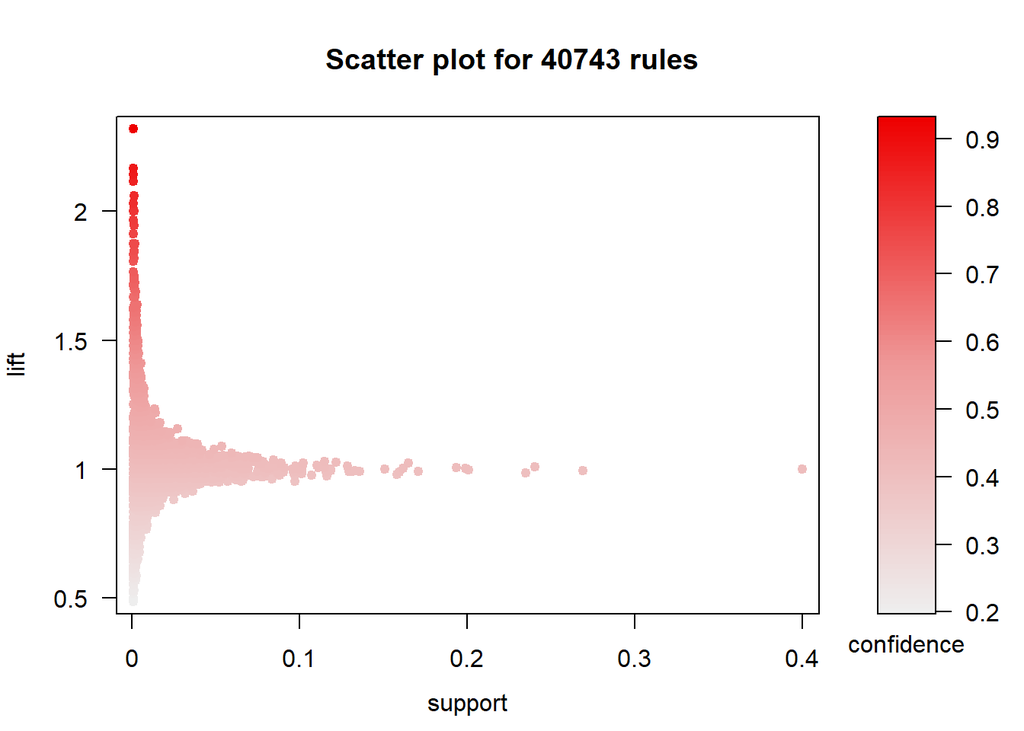

```r
plot(rules.notSatif, measure=c("support","lift"), shading="confidence", jitter = 0)
```

## Conclusions

The analysis was based on the data from the delivery companies. It gathered characteristics of the delivery services such as: rating, importance, weight, gender and so on. I used the The Apriori algorithm to see, which of the characteristics are related to customer’s ratings, which were defined as: very satisfied, quite satisfied and not satisfied.

As it turned out for the first group delivery services that were mostly on time, shipped by plane from A and F warehouse and rated by male customers got the highest values. For the second group - quite satisfied - it was hard to point out which one were associated. There were different characteristics in every rule so it was better to look at the whole rules, because characteristics combined in one way behaved different than when one characteristics was replaced. Additionally there was the higher number of rules created. When it comes to the last group for the lowest rates, in most cases delivery was from A, by road transport and rated by male customers. Values of confidence were the highest among these 3 groups.  
However the best way is to check for the characteristics in each set of rules, because in this case (where there is a lot of factors) one difference can change the result.

When there are certain characteristics connected, we can predict what will be the rate that the customer will rate the service. Of course there are no 100% guarantee that it will happen, however that gives us the basics of understanding the customers behavior.